# Assignment V

Maria Anaya

## 1. Setting up a new GitHub repository

A GitHub repository has been set up under the following link: https://github.com/maria-anaya/AssignmentV.git.

## 2. Getting to know the API

We can get the information of the following tables thanks to API: products, offers, events, attractions, areas, passwords, images, segments, venues, price-zones, prices, genres and sub-genres. Filters can be applied.

The rate limit is of 5000 calls of API per day and 5 requests per second.

In order to keep the key API secret, it is saved within another script

```r
rm(list = ls())

# API key stored in another source
source('~/AssignmentV/script key.R')
```

## 3. Interacting with the API - the basics

Before going ahead,we check if the request has been successful by checking its status. When aplying the function content(), we can see the structure of the elements (embedded, venues, name, etc), for each event venue. Once we also apply the function fromJSON(), we get different lists contained embedded, pages and links.

```r
# Loading packages needed
library(httr)
library(tibble)
library(dplyr)
library(rlist)
library(tidyverse)
library(ggplot2)



# GET request with everything
EventGermany<- GET(url="https://app.ticketmaster.com/discovery/v2/venues.json?",
                                 query=list(apikey=KeyAPI,
                                            countryCode="DE",
                                            locale="*"
                                            ))


# Check with status if query is successfully executed
status_code(EventGermany)
```

```
## [1] 200
```

```r
# Convert with content function
EventGermany_response<-content(EventGermany, as = "text", encoding = "UTF-8")


print(EventGermany)
```

```
## Response [https://app.ticketmaster.com/discovery/v2/venues.json?apikey=7elxdku9GGG5k8j0Xm8KWdANDgecHMV0&countryCode=DE&locale=%2A]
##   Date: 2021-02-16 05:02
##   Status: 200
##   Content-Type: application/json;charset=utf-8
##   Size: 12.2 kB
```

```r
# Convert with fromJSON function
EventGermany_response<-jsonlite::fromJSON(EventGermany_response,flatten=TRUE)

EventGermany_response<-EventGermany_response%>%data.frame()

# Extract information
EventGermany_response<-select(EventGermany_response,name=X_embedded.venues.name,city=X_embedded.venues.city.name,postalCode=X_embedded.venues.postalCode,address=X_embedded.venues.address.line1,url=X_embedded.venues.url,longitude=X_embedded.venues.location.longitude,latitude=X_embedded.venues.location.latitude)

# Structure of data frame obtained
glimpse(EventGermany_response)
```

```
## Rows: 20
## Columns: 7
## $ name       <chr> "Gruenspan", "Philharmonie (Großer Saal)", "Beatpol", "M...
## $ city       <chr> "Hamburg", "Berlin", "Dresden", "Ludwigsburg", "Berlin",...
## $ postalCode <chr> "22767", "10785", "01157", "71638", "12435", "79108", "7...
## $ address    <chr> "Grosse Freiheit 58", "Herbert-von-Karajan-Straße 1", "A...
## $ url        <chr> "http://www.ticketmaster.de/venue/287155", "https://www....
## $ longitude  <chr> "9.958075", "13.36896", "13.67471", "9.1824", "13.42054"...
## $ latitude   <chr> "53.551885", "52.51007", "51.06498", "48.89121", "52.499...
```

4. Interacting with the API - advanced

In order to get the remaining results pages, I add into the query list, the parameter page, so that the loop will add each page. The function Sys.sleep is used, so that the rate limit is respected.

```r
# request the venues from the remaining results pages
#page is page number and size page size
#empty table missing

n<-12175

GermanyDF<-
  data.frame(
    X_embedded.venues.name= character(n),
    X_embedded.venues.city.name = character (n)  ,
    X_embedded.venues.postalCode= character(n),
    X_embedded.venues.address.line1 = character(n),
    X_embedded.venues.url = character (n),
    X_embedded.venues.location.longitude = character(n),
    X_embedded.venues.location.latitude = character(n),
    stringsAsFactors = FALSE
  )

 for (i in 1:8) {


 test<- GET(url="https://app.ticketmaster.com/discovery/v2/venues.json?",
                                  query=list(apikey=KeyAPI,
                                             countryCode="DE",
                                             locale="*",
                                             size=25,
                                             location="*",
                                             page=(i - 1),
                                             start=((i-1)*25+1)))


 jsoncontentsearch<- content(test, as = "text", encoding = "UTF-8")


 jsoncontentsearch<-jsonlite::fromJSON(jsoncontentsearch,flatten=TRUE)%>%
   data.frame()%>%
   select(X_embedded.venues.name,X_embedded.venues.city.name,X_embedded.venues.postalCode,X_embedded.venues.address.line1,X_embedded.venues.url,X_embedded.venues.location.longitude,X_embedded.venues.location.latitude)


  GermanyDF[((i - 1) * 25+1 ):(i * 25), ] <- jsoncontentsearch


  Sys.sleep(0.2)
 }

# Structure of complete data frame
glimpse(GermanyDF)
```

```
## Rows: 12,175
## Columns: 7
## $ X_embedded.venues.name               <chr> "Gruenspan", "Philharmonie (Gr...
## $ X_embedded.venues.city.name          <chr> "Hamburg", "Berlin", "Dresden"...
## $ X_embedded.venues.postalCode         <chr> "22767", "10785", "01157", "71...
## $ X_embedded.venues.address.line1      <chr> "Grosse Freiheit 58", "Herbert...
## $ X_embedded.venues.url                <chr> "http://www.ticketmaster.de/ve...
## $ X_embedded.venues.location.longitude <chr> "9.958075", "13.36896", "13.67...
## $ X_embedded.venues.location.latitude  <chr> "53.551885", "52.51007", "51.0...
```

## 5. Visualizing the extracted data

By adding a geom_point with the data frame obtained, the locations of event venues across Germany are added. We check that the longitude and latitude respect the ranges of limit.

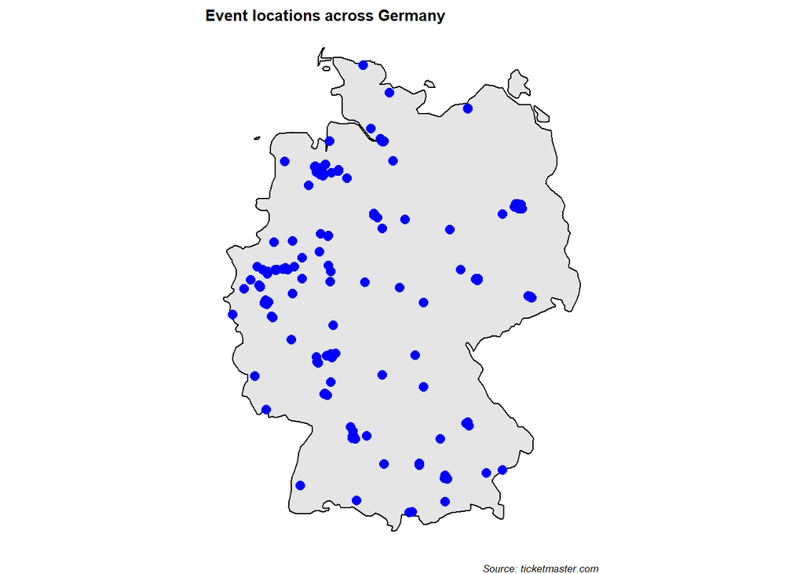

```r
# Visualizing the extracted data

# Convert latitude and longitude to numeric values
GermanyDF$X_embedded.venues.location.longitude<-as.numeric(GermanyDF$X_embedded.venues.location.longitude)
GermanyDF$X_embedded.venues.location.latitude<-as.numeric(GermanyDF$X_embedded.venues.location.latitude)


ggplot() +
geom_polygon(
aes(x = long, y = lat, group = group), data = map_data("world", region= "Germany"),
fill = "grey90",color = "black") +
geom_point(data=GermanyDF, x= GermanyDF$X_embedded.venues.location.longitude, y= GermanyDF$X_embedded.venues.location.latitude, na.rm = TRUE,color="blue",size=2.5)+
theme_void() + coord_quickmap() +
labs(title = "Event locations across Germany", caption = "Source: ticketmaster.com") +
theme(title = element_text(size=8, face='bold'),
plot.caption = element_text(face = "italic"))
```

```r
# Check values of longitude
between(GermanyDF$X_embedded.venues.location.longitude,5.866944,15.043611)

# Check values of latitude
between(GermanyDF$X_embedded.venues.location.latitude,47.271679,55.0846)
```

[output not shown]

## 6. Event locations in other countries

The country chosen is Italy. The informations that are changed, are minimized to the names of the data frames and the parameter countryCOde in the function GET.

```r
# Repeat exercises 2 to 5 for another European country of your choice.

EventItaly<-GET(url="https://app.ticketmaster.com/discovery/v2/venues.json?",
                                 query=list(apikey=KeyAPI,
                                            countryCode="IT",
                                            locale="*"
                                            ))

# Check with status if query is successfully executed
status_code(EventItaly)
```

```
## [1] 200
```

```r
# Convert with content function
EventItaly_response<-content(EventItaly, as = "text", encoding = "UTF-8")


print(EventItaly)
```

```
## Response [https://app.ticketmaster.com/discovery/v2/venues.json?apikey=7elxdku9GGG5k8j0Xm8KWdANDgecHMV0&countryCode=IT&locale=%2A]
##   Date: 2021-02-16 05:02
##   Status: 200
##   Content-Type: application/json;charset=utf-8
##   Size: 10.4 kB
```

```r
# Convert with fromJSON function
EventItaly_response<-jsonlite::fromJSON(EventItaly_response,flatten=TRUE)

EventItaly_response<-EventItaly_response%>%data.frame()

# Extract information
EventItaly_response<-select(EventItaly_response,name=X_embedded.venues.name,city=X_embedded.venues.city.name,postalCode=X_embedded.venues.postalCode,address=X_embedded.venues.address.line1,url=X_embedded.venues.url,longitude=X_embedded.venues.location.longitude,latitude=X_embedded.venues.location.latitude)

# Structure of data frame obtained
glimpse(EventItaly_response)
```

```
## Rows: 20
## Columns: 7
## $ name       <chr> "Live Club", "ITALY", "ITALY", "ITALY", "ITALY", "ITALY"...
## $ city       <chr> "Milan", "Gardone Riviera", "Rubano", "Rome", "Modena", ...
## $ postalCode <chr> "20056", "25083", "35030", "00187", "41121", "10098", "5...
## $ address    <chr> "Via Giuseppe Mazzini, 58", "Corso Zanardelli, 196", "vi...
## $ url        <chr> NA, "https://www.ticketmaster.be/venue/italy-gardone-riv...
## $ longitude  <chr> "9.5169274", NA, "11.809616", "12.477795", "10.921577", ...
## $ latitude   <chr> "45.5990796", NA, "45.421793", "41.910066", "44.644832",...
```

```r
n<-12175

ItalyDF<-
  data.frame(
    X_embedded.venues.name= character(n),
    X_embedded.venues.city.name = character (n)  ,
    X_embedded.venues.postalCode= character(n),
    X_embedded.venues.address.line1 = character(n),
    X_embedded.venues.url = character (n),
    X_embedded.venues.location.longitude = character(n),
    X_embedded.venues.location.latitude = character(n),
    stringsAsFactors = FALSE
  )

 for (i in 1:2) {


 test<- GET(url="https://app.ticketmaster.com/discovery/v2/venues.json?",
                                  query=list(apikey=KeyAPI,
                                             countryCode="IT",
                                             locale="*",
                                             size=25,
                                             page=(i - 1),
                                             start=((i-1)*25+1)))


 jsoncontentsearch<- content(test, as = "text", encoding = "UTF-8")


 jsoncontentsearch<-jsonlite::fromJSON(jsoncontentsearch,flatten=TRUE)%>%
   data.frame()%>%
   select(X_embedded.venues.name,X_embedded.venues.city.name,X_embedded.venues.postalCode,X_embedded.venues.address.line1,X_embedded.venues.url,X_embedded.venues.location.longitude,X_embedded.venues.location.latitude)


  ItalyDF[((i - 1) * 25+1 ):(i * 25), ] <- jsoncontentsearch


  Sys.sleep(0.2)
 }

# Convert latitude and longitude to numeric values
ItalyDF$X_embedded.venues.location.longitude<-as.numeric(ItalyDF$X_embedded.venues.location.longitude)
ItalyDF$X_embedded.venues.location.latitude<-as.numeric(ItalyDF$X_embedded.venues.location.latitude)
```

```r
# Check  latitude and longitude
ItalyDF$lat_it<between(ItalyDF$X_embedded.venues.location.latitude,47.5,37.56)
ItalyDF$lon_it<-between(ItalyDF$X_embedded.venues.location.longitude,6.37,18.31)
```

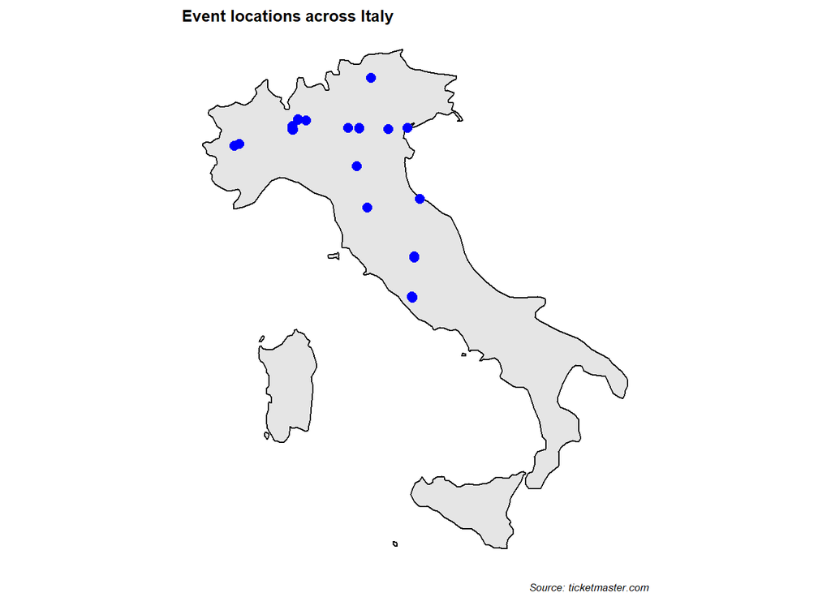

```r
ggplot() +
geom_polygon(
aes(x = long, y = lat,group=group), data = map_data("world", region= "Italy"),
fill = "grey90",color = "black") +
geom_point(data=ItalyDF, x= ItalyDF$X_embedded.venues.location.longitude, y= ItalyDF$X_embedded.venues.location.latitude, na.rm = TRUE,color="blue",size=2.5)+
theme_void()  +coord_quickmap()+
labs(title = "Event locations across Italy", caption = "Source: ticketmaster.com") +
theme(title = element_text(size=8, face='bold'),
plot.caption = element_text(face = "italic"))
```